# Reddit Comment Analysis

# 1. About Dataset

Here we are using a record of around 4.5 million reddit comments published in September 2021. The data consist of four columns, the score (Upvotes - Downvotes), the main body of the text, containing the content of the post, the “topic” and a manually labelled tag, indicating the post belongs to one of 35 categories, ranging from “International”, “Teenage” and “Gender” to “Work”, “College” and “Nature”. Each post relates to only a single tag. The topic column is simply an encoding of the categories.

The score of a comment represents the number of positive votes after subtracting all negative votes. It is important to remember that after a small threshhold of negative votes, comments are then hidden from view unless the user clicks to expand them, and as such we should expect a very extreme bias away from posts with a large number of downvotes.

Data was downloaded from: https://www.kaggle.com/datasets/vaibhavsxn/reddit-comments-labeled-data

Here we will attempt to perform an unsupervised semantic clustering to try and assess if the data’s labelling is indicative of the underlying structure of the data. We will be employing a bag of words approach utilising the NLTK python module, as well as others.

# 2. Data Overview

We’ll take a quick look at some of the main statistics of the overall dataset. Unfortunately, we don’t have access to either the poster ID or the time of posting of each comment, which are perhaps the most interesting meta statistics we could apply to the text.

When viewing our comments by score, we may wish to remove comments with a score of 1 - This is the default score when no votes have occurred and generally these posts have gone unnoticed.

The highest post score observed was just under 6000 and the lowest was -1700.

```r
table(commDat$Tag)[order(table(commDat$Tag), decreasing = T)]
```

```
##
##       Teenage           Arg          Work       College        Gender
##        467703        384308        361273        281630        239937
##            TV         Games        Social        Movies International
##        238090        225506        216538        186551        182650
##          Sell       Workout        Travel        Images        Policy
##        174775        169493        151049        138752        132578
##         Music        Nature          Guns     Treatment        Mobile
##        113862        109467        108021         87381         79255
##  Conversation        Sports   Photography      Religion         Media
##         65820         63088         53739         52025         46435
##       Fashion         Stats      Comments          Info       Laptops
##         43247         43198         37253         36556         24696
##          Food      Hardware          Pets       Spanish      Politics
##         24611         19015         18919         12784          3803
```

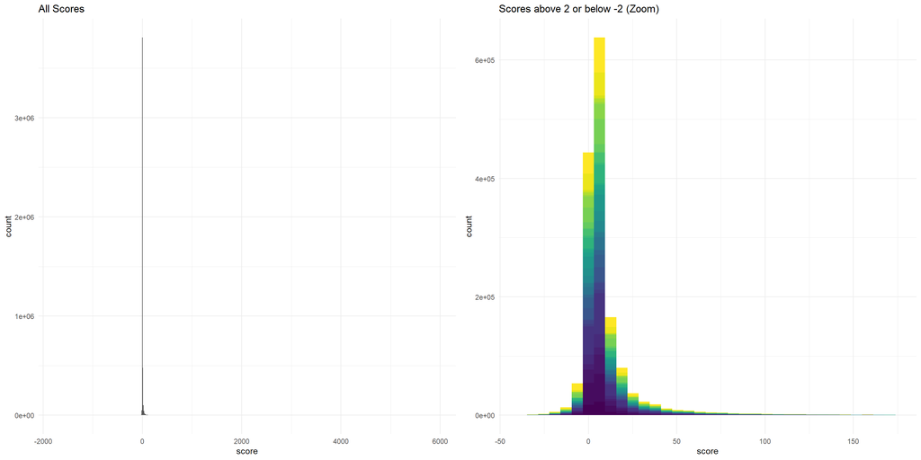

```r
g1 <- ggplot(commDat, aes(x=score)) + geom_histogram(binwidth = 10) +
          theme_minimal() + ggtitle("All Scores")

g2 <- ggplot(commDat[commDat$score > 2 | commDat$score < -2,]) + geom_histogram(aes(fill=Tag, x = score),bins = 35) +
            theme_minimal() + ggtitle("Scores above 2 or below -2 (Zoom)") + xlim(-40,175) + scale_fill_viridis(discrete = TRUE, direction = -1) +
            theme(legend.position="None")

suppressWarnings(grid.arrange(g1,g2, ncol = 2))
```

Examinng all scores together shows us that while we might have a wide total range, the vast majority of scores lie at roughly -1 to 1, generating very little activity. Around 40% of our comments have a score of 1 (The default, having generated no activity). Zooming in and ignoring scores within the range -2:2, we see that the majority of remaining scores lie above 0, around 5-10, with scores in the 2-5 range being slightly less frequent.

If we examine score ordered by topic, we might see a difference in the overall distribution of scores. Because we have so many tags, this may require splitting up the graph somewhat. As such, we’ll try to only visualize tags that we pre-suppose will have different score means. In order to do this, we perform an analysis of variance followed by a post-hoc Tukey test to search for significant differences. We will then examine more closely those tags which are separated by the largest absolute diff (And are significant).

```r
load("groupTukey.RData")
groupTukey_df <- groupTukey_df[order(abs(groupTukey_df$diff), decreasing = T),]

head(groupTukey_df, 9)
```

```
##                           diff        lwr       upr        p adj
## Teenage-Conversation  8.682425   7.771159  9.593692 0.000000e+00
## Teenage-Hardware      8.190930   6.571589  9.810271 0.000000e+00
## Nature-Conversation   7.893401   6.813741  8.973062 0.000000e+00
## Teenage-Politics      7.789037   4.225115 11.352959 4.012346e-13
## Nature-Hardware       7.401906   5.682161  9.121652 0.000000e+00
## Politics-Nature      -7.000013 -10.610664 -3.389362 7.362411e-11
## Teenage-Info          6.964550   5.775787  8.153313 0.000000e+00
## Teenage-Spanish       6.960544   4.998291  8.922798 0.000000e+00
## Gender-Conversation   6.756428   5.793279  7.719577 0.000000e+00
```

```r
group_diff <- head(groupTukey_df, 9)
```

We see that Teenage seems to have a substantially different mean than the average category. We also see an interesting diff between Nature and Hardware. Suprisingly, we might have expected Arguments to feature here, but they are missing from the top of the list. Let’s examine a couple of these comparisons.

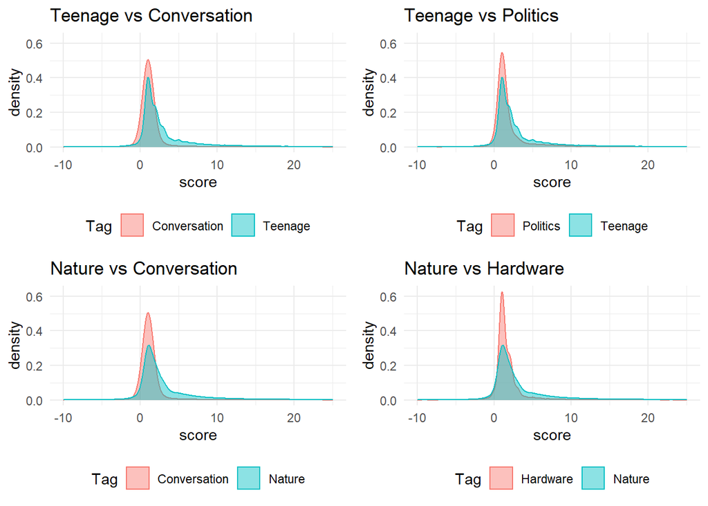

Interesting! We do see slightly different distributions for different topics. Here, we see that the topics “Teenager” and “Nature” consistently receive a score further from the default, 1, whereas topics like Conversation and Hardware consistently receive more default scores of 1. From this we might suppose that posts under the teenager and nature categories are much more likely to generate activity and be responded to/voted on. If we quickly examine the total mean score of each tag, alongside the standard error, we get a good idea about the popularity of each tag:

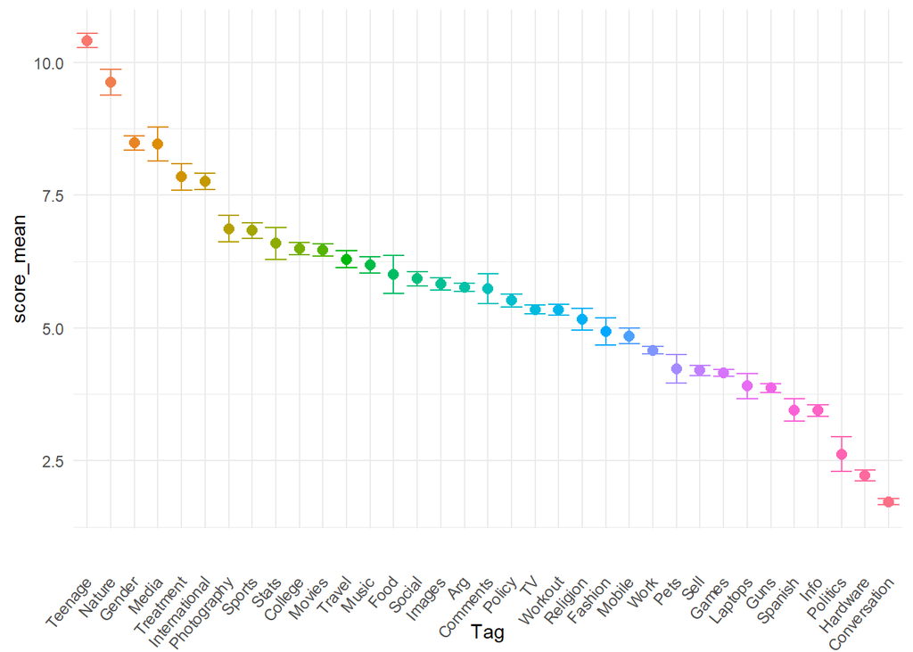

```r
commDat_agg <- aggregate(score~Tag,commDat,mean)
commDat_sd <- aggregate(score~Tag,commDat, FUN = function(x) std.error(x))
colnames(commDat_agg) <- c("Tag","score_mean")
colnames(commDat_sd) <- c("Tag","score_sem")

commDat_agg2 <- merge(commDat_agg,commDat_sd,by="Tag")

commDat_agg2$Tag <- factor(commDat_agg2$Tag, levels = commDat_agg2[order(commDat_agg2$score_mean, decreasing = T),]$Tag)

ggplot(commDat_agg2, aes(x=Tag,y=score_mean, colour=Tag)) + geom_point(size=2.5) + geom_errorbar(aes(ymin=score_mean-score_sem,ymax=score_mean+score_sem)) + theme_minimal() +
  theme(axis.text.x = element_text(angle = 50, vjust = 0.5, hjust=1), legend.position = "None")
```

Wow! For such a large category, Teenage having the highest mean score is certainly interesting - Both the most active category in terms of posts, and in terms of generative upvote activity. Nature, Gender and Media are perhaps more expected as highly upvoted topics. Interestingly, Conversation, Hardware and Politics have a very low mean upvote score - Perhaps this makes sense, as these topics might be considered slightly “boring”.

# 3. Unsupervised clustering

Now, we already have 35 categories, but some of these categories may be very close to eachother in terms of content and have an unnecessary separation. One technique we could use to decypher this would be to employ an unsupervised clustering technique on the body of the text of each post - A semantic clustering. We might expect that the difference between “Music” and “Media” may be largely superficial, and in semantic context, these posts are generally very similar. We may see that “Teenage” clusters into several sub-clusters which we may need to further delineate.

Our first step is to clean the text body. For example, removing links and URLs, etc. We will also have to subsample the data due to the fact that calculating a distance matrix with 4.5 million rows is not feasible. We will do this in a stratified manner in order to preserve the different tag frequencies.

After this, we will perform further text cleaning, such as the removal of punctuation, stop words and white spaces using NLTK. We will also be removing words that have a very low frequency because, with such a large number of comments, it’s very important to reduce our feature space to something our computer power can handle.

Our aim is to generate a matrix from our clean corpus of vectorised and TF-IDF adjusted posts that we can then submit to clustering.

This will be performed in python for convenience, as below.

```r
allDat = pd.read_csv("Comments_Sub.csv")
labels = allDat["Tag"]
#Remove URLS and whitespace
allDat['body'] = allDat['body'].str.strip()
allDat['body'] = allDat['body'].str.replace('http[s]?://(?:[a-zA-Z]|[0-9]|[$-_@.&+]|[!*\(\),]|(?:%[0-9a-fA-F][0-9a-fA-F]))+', ' ',regex=True)

#Inititate vectorizer
cv = TfidfVectorizer(lowercase=True,
                         stop_words='english',
                         ngram_range=(1, 1),
                         tokenizer=word_tokenize, max_df = 0.975, min_df = 0.01)
X = cv.fit_transform(allDat["body"])

#Perform dimensionality reduction and normalize
svd = TruncatedSVD()
normalizer = Normalizer(copy=False)
lsa = make_pipeline(svd, normalizer)
X = lsa.fit_transform(X)

#Perform clustering
km = KMeans(max_iter=100, n_init=10)
km.fit(X)

X_out = pd.DataFrame(X)
X_out["label_old"] = labels
X_out["labels_new"] = km.labels_
X_out.to_csv("KMeans.csv")
```

Running this over our input comment data, we arrive at 8 cluster assignments. Quite different from our 35 starting Tags. Indeed, cluster overlap metrics indicate how different these two groupings are, with a homogeneity of 0.05 and an adjusted RAND index of 0.024 - They couldn’t be more different.

To visualise this, we might struggle to plot each of the 450,000 comments after dimensionlity reduction, but we can attempt to plot the centroids of the old 35 clusters versus the centroids of the new 8 clusters.

## Kmeans plots

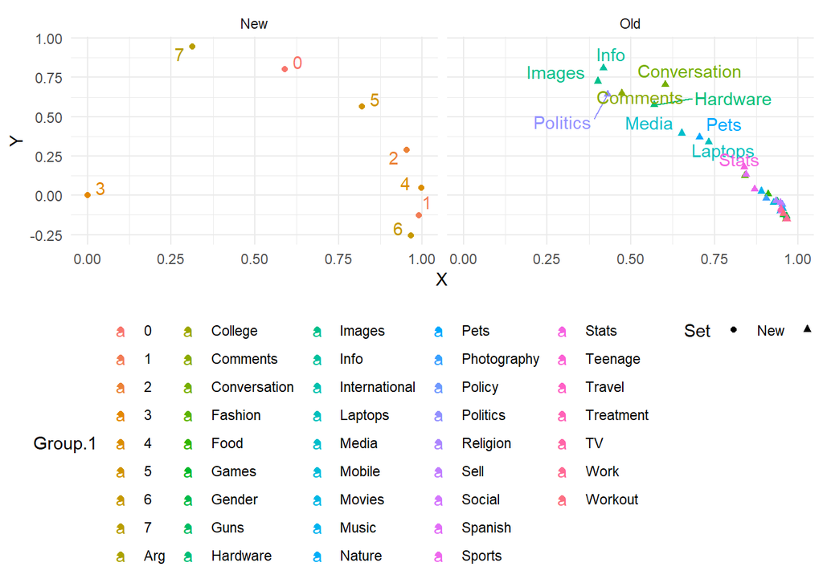

```r
kmeans_dat <- read.csv("KMeans.csv")
colnames(kmeans_dat) <- c("Index","X","Y","old_labels","new_labels")

centroids_old <- aggregate(kmeans_dat[,c(2,3)],by = list(kmeans_dat$old_labels),mean)
centroids_new <- aggregate(kmeans_dat[,c(2,3)],by = list(kmeans_dat$new_labels),mean)
centroids_old$Set <- "Old"
centroids_new$Set <- "New"
centroids_all <- rbind(centroids_old,centroids_new)

ggplot(centroids_all, aes(x=X,y=Y,colour=Group.1,shape=Set)) +
  geom_point() + ggrepel::geom_text_repel(aes(label=Group.1)) +
  facet_wrap(~Set, nrow = 1) +
        theme_minimal() + theme(legend.position = "bottom")
```

```r
table(kmeans_dat[kmeans_dat$new_labels==3,]$old_labels)
```

```
##
##           Arg       College      Comments  Conversation       Fashion
##            60            58           305            74            79
##          Food         Games        Gender          Guns      Hardware
##            31           107            39            98            35
##        Images          Info International       Laptops         Media
##           833            71            40            96           351
##        Mobile        Movies         Music        Nature          Pets
##            98            85           129            32            79
##   Photography        Policy      Politics      Religion          Sell
##           109            53            50            39            72
##        Social       Spanish        Sports         Stats       Teenage
##            97            35           119           192            32
##        Travel     Treatment            TV          Work       Workout
##            66            53            80            46            93
```

## Cluster Analysis

```r
print("Cluster 3")
```

```
## [1] "Cluster 3"
```

```r
allDat_processed <- readr::read_csv("allDat_Sub_test.csv")
```

```
## -------------------------------------------------------- Delimiter: "," chr
## (4): Tag, body, TagGroup, labels_test dbl (5): ...1, Unnamed: 0, score, Topic,
## labels_new
```

```r
clus3_corpus <- tm::VCorpus(VectorSource(allDat_processed[allDat_processed$labels_new==3,]$body))
clus3_freq <- as.data.frame(termFreq(allDat_processed[allDat_processed$labels_new==3,]$body))

rownames(clus3_freq)[c(10:20)]
```

```
##  [1] "//fhjvls9sir8ph8sxzz7bsoa2zcf2lgqzlem1rkveq0sx6x8klymldjmvkllapo"
##  [2] "//rjb49ir65ici+fmq+0ag/uygsizxm5xzlsku/p6ujpgpi37vqyn2anfavtrehg"
##  [3] "//rkxesfctzd/zmw3bahnv81noobhm1g5p6rcwpricvdaymjppbdzptq/y8mxf0f"
##  [4] "//wgupxfgtmq/olgxluzpq6oky9ok0arp3pnptdqdgxrtwesvhsr57wclmbf/ssd"
##  [5] "/++aa7xak4cogql/+9lsska8ts8s59car80ehzj5jzmd3buspnp8otq7xnsvlppw"
##  [6] "/++cqfnp2gpx/fqhexo/9z4h0wqo3b5jeh3llhinapldomo2krxcoeb/pjk+bvfg"
##  [7] "/+2pdpmvh0fuutfban48smgy0nix2aqztqzfhcpolwhmn5wkzdp94ydeqj9c2aye"
##  [8] "/+5yrv6vbufpd7lbpsqn+euliynpfjmpqegmpkyghdee10sahgihgjrarifheigi"
##  [9] "/+67edjmiscjliuztigsirjewq5iw10art+e7jbsb+urjfd1xr3t2hpuny8oxrif"
## [10] "/+7yquyywa89sqvdt2wy4+p/fgq3syiiudpiwbia2fvqglmhfg7ep/d2jk7jqaw5"
## [11] "/+cykpjfd0er3gcq0sgbivyxubykrmtx4jfskvmvherzet3uw99dkzhjgeo0ule+"
```

Wow! This is actually incredibly interesting. These long, apparently nonsense, strings are, in fact, scams. Designed to not appear as links to users of reddit mobile, these also managed to bypass our link-removing regex term. Discovering these posts manually, or attempting to design a regex to find them, would have been a great challenge, but our k-means clustering has identified them as outliers very effectively and quarantined them off to one side of our plot, something that the manual labelling completely missed. Clicking on these links will take reddit users to sites which contain malware, and their discovery is a useful proof of methodology for clustering these comments.

When looking at our other cluster centroids, we might expect that cluster 7 would be associated with the top-left group of Tags: Images, Info, Comments and Politic. Just for the purpose of exploring these clusters, we’ll remove the terms most frequent in the overall body of text and remove them, analogous to our python script.

```r
print("Cluster 7")
```

```
## [1] "Cluster 7"
```

```r
clus7_corpus <- tm::VCorpus(VectorSource(allDat_processed[allDat_processed$labels_new==7,]$body))
clus7_freq <- as.data.frame(termFreq(allDat_processed[allDat_processed$labels_new==7,]$body))
clus7_freq$term <- rownames(clus7_freq)
colnames(clus7_freq)[1] <- "freq"

clus7_freq <- clus7_freq[order(clus7_freq$freq, decreasing = T),]

clus7_freq[c(30:40),]
```

```
##            freq       term
## nsfw       2568       nsfw
## ^also      2549      ^also
## ^parent    2544    ^parent
## [^(faqs)]( 2542 [^(faqs)](
## ^-1        2542        ^-1
## ^commenter 2542 ^commenter
## ^delete    2542    ^delete
## ^less.     2542     ^less.
## [^toggle   2540   [^toggle
## ^or[](#or) 2540 ^or[](#or)
## [](#sfw)   2539   [](#sfw)
```

Well, when examining this data from the overall data, the term that stands out the most, by far, is that of the 2812 references to “NSFW”, 2568 were in cluster 7. “NSFW” meaning not safe for work, generally references 18+ images. Why these are clustered with Info and Politics is unclear, but considering how small both of these categories were initially, it is possible that the majority of comments within them were mislabeled. Other high-frequency cluster7 terms include “Newegg”, “Amazon” and “SuperBiiz”, two online computer-parts stores, which are reflected by the relatively high frequency of “Hardware” tags also present in cluster7. Why NSFW and buying computer parts cluster together is a little unclear!

```r
print("Cluster 5")
```

```
## [1] "Cluster 5"
```

```r
table(allDat_processed[allDat_processed$labels_new==5,]$labels_test)
```

```
##
##           Arg       College      Comments  Conversation       Fashion
##           943           603           201           811           321
##          Food         Games        Gender          Guns      Hardware
##           186           602           659           582            79
##        Images          Info International       Laptops         Media
##           484           136           827           329           498
##        Mobile        Movies         Music        Nature          Pets
##           508           787           704           514           121
##   Photography        Policy      Politics      Religion          Sell
##           274           698             5           265           985
##        Social       Spanish        Sports         Stats       Teenage
##           821            88           321           476          1019
##        Travel     Treatment            TV          Work       Workout
##           604           416           880           742           522
```

```r
clus5_corpus <- tm::VCorpus(VectorSource(allDat_processed[allDat_processed$labels_new==5,]$body))
clus5_freq <- as.data.frame(termFreq(allDat_processed[allDat_processed$labels_new==5,]$body))

clus5_freq$term <- rownames(clus5_freq)
colnames(clus5_freq)[1] <- "freq"
clus5_freq <- clus5_freq[order(clus5_freq$freq, decreasing = T),]

clus5_freq[c(30:40),]
```

```
##         freq    term
## there   3775   there
## get     3725     get
## any     3667     any
## their   3616   their
## out     3582     out
## when    3484    when
## don't   3326   don't
## which   3246   which
## also    3171    also
## because 3071 because
## other   3054   other
```

Hmmm… Very hard to tell. Certainly the smaller clusters seem to have quite a well defined theme, but the larger clusters are harder to decypher. One issue here is likely to be our dimensionality reduction and transformation technique, which could likely afford to be more sophisticated.